# CRT_test

2023-11-29

```r
library(glmnet)
library(rags2ridges)
library(glasso)
library(Matrix)
library(MASS)
library(mvtnorm)
library(reshape)
library(ggplot2)
source("CRT-Simulate.R")
source("CRT-Stat.R")
source("DBL_GLMs_functions.R")
source("OneExp.R")
source("Run-Testing.R")
source("dCRT_function.R")
source("GoF-Settings.R")
source("CSS-GGM.R")
source("GGMTesting.R")
source("CIT_function_for_webpage.R")
```

# Conditional independece testing

We consider a range of regression models for $\mathcal{L}(Y\mid X)$, including linear regression, logistic regression, nonlinear regression, and nonlinear binary regression. For each regression model, we consider a low-dimension setting ($p=20$ and $n=50$) and a high-dimension setting ($p=120$ and $n=80$). Our tests are compared with various established testing methods.

In each experiment, we randomly permute the nodes of a band graph with $K=6$ and $s=0.2$, and denote by $G$ the resulting graph and by $\mathbf{\Omega}$ the precision matrix. Without loss of generality, we assume $\mathbf{\Omega}$ has been standardized so that the diagonal elements of $\mathbf{\Omega}^{-1}$ all equal to 1.

We consider testing $H_0: Y \perp\!\!\!\perp X_{\mathcal{T}} | X_{-\mathcal{T}}$ at the significance level $0.05$ for $\mathcal{T}=\{1,2,\ldots, 8\}$.

## Looking into the CRT function

Take the Gaussian linear regression for example

```r
setting = "l_l_w"                 # gaussian linear regression (low-dimensional setting)
n = c(50)
p = c(20)
setT=1:8

K = 6
s = 0.2
grid_signal= seq(0,2.5,by=0.25)   # control signal strength

# get graph G
true_graph=graph_band(p,K,s)
perm.var=sample(p,p)
sigma=true_graph$sigma[perm.var,perm.var]
inv.sigma=true_graph$inv.sigma[perm.var,perm.var]
diag_s=sqrt(diag(sigma))
sigma=sweep(sweep(sigma,1,1/diag_s,"*"),2,1/diag_s, "*")
inv.sigma=sweep(sweep(inv.sigma,1,diag_s,"*"),2,diag_s, "*")
G = prec_to_adj(inv.sigma)       # graph G

# Simulate the data X
X <- simulate_data(sigma, n)
beta=random_beta(p)              # regression coefficient
noise_unif=runif(n)
```

Sampling M exchangeable copies of X, L is the number of iterations in each Markov chain (Algorithm 2)

```r
CSS_sample = exchangeable_sampling(X, G, I = setT, bReduced = T, M=100, L=3)
X_copies  = CSS_sample$X_copies
```

We choose statistics LM-SST and LM-SSR by comparison to the classical F-test for the null hypothesis $H_0: \beta_{\mathcal{T}}=0$ and the dCRT using a Gaussian Lasso model (Bonferroni adjusted).

```r
# statistics
List_Stat_Comb=c("Stat_Comb_Linear_SST","Stat_Comb_Linear_Dev")
```

CRT test (Algorithm 4)

```r
test_result = GRT_test_webpage(X, CSS_sample, setting, setT, beta, niose_unif, grid_signal, List_Stat_Comb,IncludeBaseline = T)
```

Output the p-value

```r
for(ind.signal in 1:length(grid_signal)){
  print(paste("theta=",test_result[[ind.signal]]$theta))
  output_pvalue = test_result[[ind.signal]]$pvalues[-which(names(test_result[[ind.signal]]$pvalues)=="dCRT_RF")]
  names(output_pvalue) = c("LM-SST","LM-SSR","F-test","dCRT")
  print(output_pvalue)
}
```

```
## [1] "theta= 0"
##     LM-SST     LM-SSR     F-test       dCRT
## 0.26732673 0.19801980 0.13321266 0.01254967
## [1] "theta= 0.25"
##     LM-SST     LM-SSR     F-test       dCRT
## 0.19801980 0.14851485 0.13382489 0.03014476
## [1] "theta= 0.5"
##     LM-SST     LM-SSR     F-test       dCRT
## 0.06930693 0.09900990 0.09486605 0.05637199
## [1] "theta= 0.75"
##     LM-SST     LM-SSR     F-test       dCRT
## 0.01980198 0.03960396 0.04735235 0.06486988
## [1] "theta= 1"
##     LM-SST     LM-SSR     F-test       dCRT
## 0.00990099 0.02970297 0.01694430 0.13930592
## [1] "theta= 1.25"
##      LM-SST      LM-SSR      F-test        dCRT
## 0.009900990 0.009900990 0.004565166 0.344127913
## [1] "theta= 1.5"
##       LM-SST       LM-SSR       F-test         dCRT
## 0.0099009901 0.0099009901 0.0009921595 0.4716302141
## [1] "theta= 1.75"
##       LM-SST       LM-SSR       F-test         dCRT
## 0.0099009901 0.0099009901 0.0001867632 0.2330930782
## [1] "theta= 2"
##       LM-SST       LM-SSR       F-test         dCRT
## 9.900990e-03 9.900990e-03 3.238394e-05 1.551405e-01
## [1] "theta= 2.25"
##       LM-SST       LM-SSR       F-test         dCRT
## 9.900990e-03 9.900990e-03 5.425806e-06 7.919436e-02
## [1] "theta= 2.5"
##       LM-SST       LM-SSR       F-test         dCRT
## 9.900990e-03 9.900990e-03 9.092498e-07 2.481656e-02
```

Take theta = 0, statistics: LM-SST for example

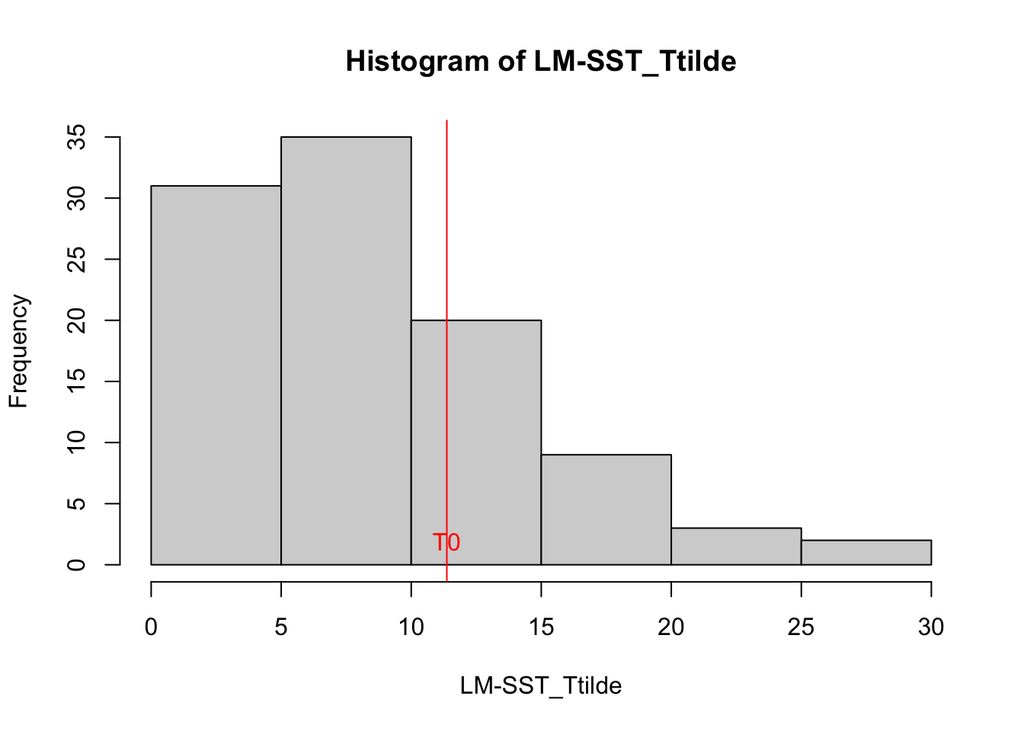

```r
hist(test_result$`theta= 0`$Ttildes$Stat_Comb_Linear_SST,xlab = "LM-SST_Ttilde",main="Histogram of LM-SST_Ttilde")
abline(v=test_result$`theta= 0`$T0s$Stat_Comb_Linear_SST,col="red")
text(test_result$`theta= 0`$T0s$Stat_Comb_Linear_SST, 0,labels = "T0", pos = 3, col = "red")
```

## Repeat experiments

Take the Gaussian linear regression for example

```r
# Set parameters
popul_param_llw <- list(
  setting = "l_l_w",
  N = c(50),
  P = c(20),
  setT=1:8,
  modelParam = list(
    K = 6,
    s = 0.2,
    grid_signal= seq(0,2.5,by=0.25)
  )
)
```

```r
path_prefix=paste0('Experiments-llw','/')
if(!dir.exists(path_prefix)){
  dir.create(path_prefix)
}

# Repeat experiment and save results
for (epo in 1:2){
  output = CRT_webpage(popul_param_llw,epo = epo)
  save(output,popul_param_llw,file=paste0(path_prefix,epo,'.RData'))
}

# Load results
all_output=list()
for(epo in 1:2){
  load(file=paste0(path_prefix,epo,'.RData'))
  all_output[[epo]]=output
}

combined_pvalues=list()
for(ind.signal in 1:length(popul_param_llw$modelParam$grid_signal)){
  combined_pvalues[[ind.signal]]=t(sapply(all_output, function(v)v[[ind.signal]]$pvalues))
}
combined_pvalues=lapply(combined_pvalues,function(x)x[,-c(5)])
combined_pvalues=lapply(combined_pvalues,function(x){
  colnames(x)=c("LM-SST","LM-SSR","F-test","dCRT")
  return(x)})
```

Present the power of various testing methods in the experiment, in which power is presented against varying values of $\theta$

```r
Fun_SE=function(x){sd(x)/sqrt(length(x))}

pvalues_array=simplify2array(combined_pvalues)
sig.lv=0.05

power_table=data.frame(apply(pvalues_array<sig.lv, 3:2,mean));
power_SE_table=data.frame(apply(pvalues_array<sig.lv, 3:2,Fun_SE))

num_methods=ncol(power_table)
power_table$theta=popul_param_llw$modelParam$grid_signal
power_SE_table$theta=popul_param_llw$modelParam$grid_signal



df_melt=melt(power_table,id.vars="theta", variable_name = "Test")
df_melt$Power=df_melt$value;df_melt$value=NULL

SE_melt <- melt(power_SE_table, id.vars = "theta", variable_name = "Test")
SE_melt$SE=SE_melt$value;SE_melt$value=NULL

# Merge the data and SE data frames
merged_df <- merge(df_melt, SE_melt, by = c("theta", "Test"))
print(merged_df)
```

```
##    theta   Test Power  SE
## 1   0.00   dCRT   0.0 0.0
## 2   0.00 F.test   0.0 0.0
## 3   0.00 LM.SSR   0.0 0.0
## 4   0.00 LM.SST   0.0 0.0
## 5   0.25   dCRT   0.0 0.0
## 6   0.25 F.test   0.0 0.0
## 7   0.25 LM.SSR   0.0 0.0
## 8   0.25 LM.SST   0.0 0.0
## 9   0.50   dCRT   0.0 0.0
## 10  0.50 F.test   0.0 0.0
## 11  0.50 LM.SSR   0.0 0.0
## 12  0.50 LM.SST   0.0 0.0
## 13  0.75   dCRT   0.0 0.0
## 14  0.75 F.test   0.0 0.0
```

[output cut: 30 more lines]